# New Perspective on Stock Price Trend Resistance and Support

#### — Study in devising a new indicator based market timing model

### **Cheng Ximen, CFA, FRM**

**list of content**

1. Introduciton
2. Indicator Construction
3. Model Testing

If you do not wish to see the raw code in this report please click the button below

```python
%%HTML
<button onclick="$('.input, .prompt, .output_stderr, .output_error, .output_result').toggle();">Hide Code</button>
```

## 1. Introduction

**Some personal background story**

It has always been one of my main interest in making sense of the world based on statistical findings, which greatly satisfies my curiosities as well as my passion for math. During my recent employment in PE fund for primary equity market, one of my main duty is to study industry and business trends and to derive guidelines in selecting best investment opportunities. However unless there are large listed companies in the target industry, a lot of times key industry and business data are protected as trade secrets and are not openly available, thus the more effective ways in doing research during work are through conversing with business insiders and industry experts and through field trip study, as oppose to deriving the conclusions through statistical findings. On the other hand, trade data and financial data are very comprehensive and readily available in the secondary equity market, so I have kept it as a hobby to play with the data, devise and back test quantative investment models. Through time I have created a few models that I feel confident to use in real-time stock market. Partnered with a friend, we entered into a business venture to form a PE fund that invest in mainland China stock market with those models. Even though the business venture didn’t end up in success, I had great fun in the process. Those studies also turn out to be great exercise in improving my coding and modeling capabilities. This report is based on the result of my study in devising a market timing model for the PE fund business venture.

**Where the inspiration came from**

The argument that whether we are able to perform market timing that leads to better investment return than simple buy and hold or dollar cost averaging strategy, may have exsisted since the beginning of stock market. The same question has baffled me since I first got into finance, so as soon as I learned how to code and backtest models, I have tried all the popular technical indicators and other market timing strategies on mainland China stock indices. It turned out there're several trend following technical indicators, particularly MA20, MACD, can improve investment return and reduce the drawdown, at least in stock market in mainland China, however those indicators tend to perform poorly in dull market and the signals tend to lag the trend quite a bit. There should be a way to better detect and reflect current market conditions.

There's a saying that "market always move in the path of the least resistance". If we can better detect the changes of current resistance and support, maybe we can better predict the future price direction. A traditional technical analyst or chart analyst will compare recent lows and recent highs to detect how resistance and support level change. By Quantifying the changes through mathematical equations, we should be able to build a model to automate the process and accomplish the same thing based on this idea. This is the main thought process behind the scene.

## 2. Indicator Construction

```python
# import libraries

import statsmodels.formula.api as sml
import pandas as pd
import numpy as np
import talib as tb
import altair as alt
import matplotlib
%matplotlib inline
alt.data_transformers.disable_max_rows()
```

```
DataTransformerRegistry.enable('default')
```

**Data**

We'll perform our analysis and testing based on price data of CSI300. The CSI 300 is a capitalization-weighted stock market index designed to replicate the performance of top 300 stocks traded in the Shanghai and Shenzhen stock exchanges. It contains the daily open, close, high, low prices from 2005 to the time this report is last updated. Below is how the table looks like.

```python
price_df = pd.read_csv('price_data.csv',index_col=0)
pd.set_option('display.max_rows', 10)
price_df
```

|  | open | close | high | low |
| --- | --- | --- | --- | --- |
| 2005-05-16 | 885.39 | 875.27 | 885.39 | 869.33 |
| 2005-05-17 | 873.08 | 881.46 | 888.28 | 868.21 |
| 2005-05-18 | 881.14 | 883.20 | 890.40 | 871.82 |
| 2005-05-19 | 882.84 | 884.17 | 888.02 | 871.29 |
| 2005-05-20 | 883.51 | 882.76 | 891.02 | 879.18 |
| ... | ... | ... | ... | ... |
| 2019-08-19 | 3736.03 | 3791.09 | 3791.09 | 3720.69 |
| 2019-08-20 | 3786.03 | 3787.73 | 3799.90 | 3778.73 |
| 2019-08-21 | 3778.31 | 3781.76 | 3792.60 | 3775.45 |
| 2019-08-22 | 3793.86 | 3793.51 | 3797.33 | 3771.20 |
| 2019-08-23 | 3796.88 | 3820.86 | 3829.36 | 3788.03 |

3478 rows × 4 columns

let’s add a daily return column and do a simple analysis to get a sense of the market performance.

```python
# add kurtosis and skewness in describe
def describe(series):
    result = series.describe()
    result['Kurtosis'] = series.kurtosis()
    result['Skewness'] = series.skew()
    return result
```

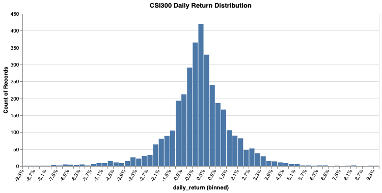

```python
price_df['daily_return'] = (price_df.close-price_df.close.shift(1))/price_df.close.shift(1)
# plot daily return distribution chart
alt.Chart(price_df).mark_bar().encode(
    alt.X("daily_return:Q", bin=alt.Bin(step=0.003), axis=alt.Axis(format='%',labelAngle=-60)),
    y='count()',
).properties(title = 'CSI300 Daily Return Distribution',width=700)
```

```python
# check daily return basic statistics info
describe(price_df.daily_return)
```

```
count       3477.000000
mean           0.000577
std            0.017442
min           -0.092400
25%           -0.007130
50%            0.000901
75%            0.009054
max            0.093418
Kurtosis       3.618487
Skewness      -0.376883
Name: daily_return, dtype: float64
```

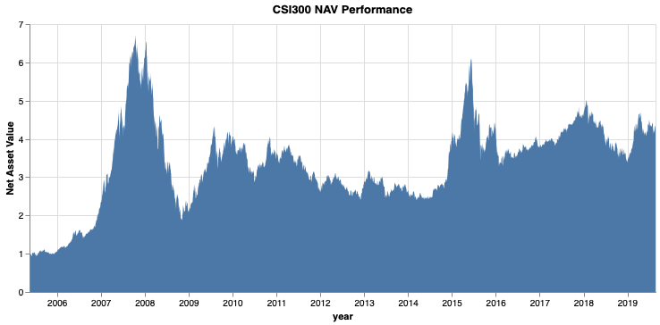

```python
# NAV for CSI300 buy and hold strategy
price_df['CSI300_Net_Value'] = (price_df.daily_return+1).cumprod()
# plot NAV chart
alt.Chart(price_df.reset_index()).mark_area().encode(
    x = alt.X('index:T',title = 'year'),
    y=alt.Y("CSI300_Net_Value:Q", title = 'Net Asset Value')
   ).properties(title = 'CSI300 NAV Performance',width=700)
```

**Backtesting of Traditional Trend Following Indicators**

To illustrate my view in market timing mentioned above, I’ll first perform a simple back testing on models based on MA20. **P.S. Backtesting model here used the simplest design just to evaluate the effectiveness of the strategy, so didn’t take into the account of a lot of real world factors that might affect the investment performance such as slippage and commission fee etc.**

```python
# define a function to calculate Strategy NAV
def cal_NAV(hold_status,StrategyName):
    Strategy_NAV = (price_df.daily_return[hold_status.index]*hold_status.astype('int64')+1).cumprod()
    CSI300_NAV = (price_df.daily_return[hold_status.index]+1).cumprod()
    return pd.DataFrame({
        StrategyName:Strategy_NAV,
        'CSI300':CSI300_NAV
    }).reset_index().melt('index')
```

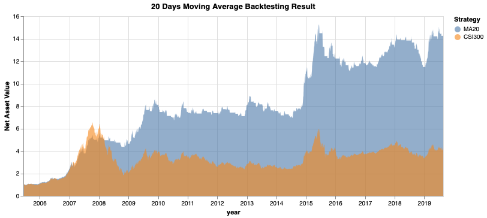

```python
# Calculate daily MA20 Value
MA20  = tb.MA(price_df.close,20).dropna()
# If yesterday's close price over MA20 value hold stock position, otherwise close position.
MA20_holdingStatus = (price_df.close[MA20.index]>MA20).shift(1).dropna()
chart_df = cal_NAV(MA20_holdingStatus,'MA20')
alt.Chart(chart_df).mark_area(opacity=0.6).encode(
                    x = alt.X('index:T',title = 'year'),
                    y=alt.Y("value:Q", stack=None, title = 'Net Asset Value'),
                    color = alt.Color('variable:N',title = 'Strategy',sort = ['MA20','CSI300'])
                ).properties(title = '20 Days Moving Average Backtesting Result',width=700)
```

As we can see form the chart, even a strategy as simple as 20 days moving average can prove to be quite effective in enhancing portfolio return, which I believe can prove that trend following does work in stock market in mainland China. And we can see that it fails to escape the pull back in 2015 and 2018, so let’s continue to construct an indicator that works better.

**Quantify Resistance and Support**

As mentioned above, according to traditional technical analysis the key to predict price direction is to evaluate the changes in resistance and support level. If at current price level support is stronger than resistance, we should expect price to go up and vice versa. If we look at the intraday market, the lowest point can be the support level of the day and the highest point can be the resistance level of the day. Now to quantify the changes in the strength of resistance and support, we just need to regress the lows against the highs of each day for N periods of days, where N should be large enough to average out the noise in daily price and small enough to be responsive to changes in market condition.

High = alpha + beta*low + epsilon, epsilon ~ N(0,sigma)

When beta is large, it means support is stronger than resistance, we can say price is likely to go up and vice versa. To illustrate my point.Let’s see what high beta and low beta price action looks like in uptrending and down trending market.

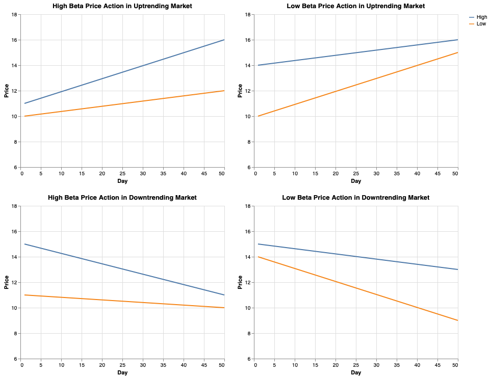

```python
upTrend_highBeta_df = pd.DataFrame({
    'Day':np.linspace(1,50).astype('int'),
    'High':np.linspace(11,16,num=50),
    'Low':np.linspace(10,12,num=50)
}).melt('Day')
upTrend_highBeta_df.name = 'High Beta Price Action in Uptrending Market'
upTrend_lowBeta_df = pd.DataFrame({
    'Day':np.linspace(1,50).astype('int'),
    'High':np.linspace(14,16,num=50),
    'Low':np.linspace(10,15,num=50)
}).melt('Day')
upTrend_lowBeta_df.name = 'Low Beta Price Action in Uptrending Market'
downTrend_highBeta_df = pd.DataFrame({
    'Day':np.linspace(1,50).astype('int'),
    'High':np.linspace(15,11,num=50),
    'Low':np.linspace(11,10,num=50)
}).melt('Day')
downTrend_highBeta_df.name = 'High Beta Price Action in Downtrending Market'
downTrend_lowBeta_df = pd.DataFrame({
    'Day':np.linspace(1,50).astype('int'),
    'High':np.linspace(15,13,num=50),
    'Low':np.linspace(14,9,num=50)
}).melt('Day')
downTrend_lowBeta_df.name = 'Low Beta Price Action in Downtrending Market'

chart = alt.vconcat()
for col_list in [[upTrend_highBeta_df, upTrend_lowBeta_df],[downTrend_highBeta_df, downTrend_lowBeta_df]]:
    row = alt.hconcat()
    for df in col_list:
        row |= alt.Chart(df).mark_line().encode(
                    x = 'Day:Q',
                    y=alt.Y("value:Q", title = 'Price',scale = alt.Scale(domain=[6,18])),
                    color = alt.Color('variable:N',title = None)
                ).properties(
                    title = df.name
                )
    chart &= row
chart
```

To further explain the price action in the chart, let me take the top left chart as an example. We are likely to see the price action in this chart at the beginning of a bull market, where even though the price will still revert to low level, but it can make new highs more and more frequently, which means the resistance level is weak while the support is strong.

Now let's do some coding to calculate daily beta value. Here we set the fit period to 18 days.

```python
fit_period = 18
for i in range(fit_period-1,len(price_df)):
    df=price_df.iloc[i-fit_period+1:i+1]
    model = sml.ols(formula='high~low',data = df)
    result=model.fit()
    price_df.loc[df.iloc[-1].name,'beta'] = result.params[1]
    price_df.loc[df.iloc[-1].name,'R2'] = result.rsquared
```

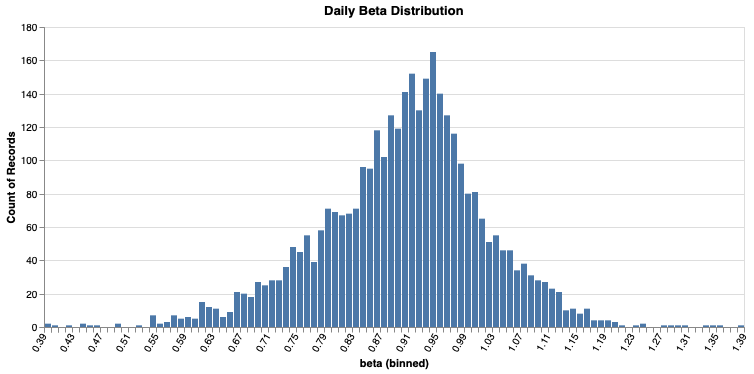

```python
# plot daily return distribution chart
alt.Chart(price_df.dropna()).mark_bar().encode(
    alt.X("beta:Q", bin=alt.Bin(step=0.01),axis=alt.Axis(labelAngle=-60)),
    y='count()',
).properties(title = 'Daily Beta Distribution',width=700)
```

```python
# # check beta basic statistics info
describe(price_df.beta)
```

```
count       3461.000000
mean           0.902730
std            0.117484
min            0.393611
25%            0.837102
50%            0.912230
75%            0.973638
max            1.386718
Kurtosis       0.922006
Skewness      -0.337912
Name: beta, dtype: float64
```

Now we have the beta value for each day. We can come up with a strategy that hold stock when beta is over 1 and sell when beta is below 0.8. The threshold levels are set based on historical data, however in real world since the market condition is constantly changing, the standard deviation and mean for beta is changing as well. if we plot the moving average of beta value for the past year we can see it’s varying by pretty large degree.

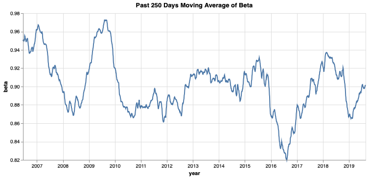

```python
alt.Chart(price_df[['beta']].rolling(window = 250).mean().reset_index().dropna()).mark_line().encode(
    x = alt.X('index:T',title = 'year'),
    y=alt.Y('beta:Q',scale = alt.Scale(zero=False))
   ).properties(title = 'Past 250 Days Moving Average of Beta',width=700)
```

One way to solve the problem is to normalize the data and to include a full bull and bear market cycle let's use the past five years data to do the calculation. And sometimes in unusual period of time the price will move very dramatically due to news impact such as the trade war between US and China. Since SML model are sensitive to outliers, these data point tend to have a big effect on the beta as well. In order to increase the robustness of the indicator, we can penalize those data point by multiplying the R squared.

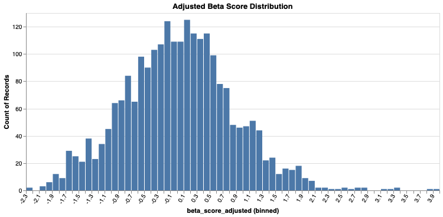

```python
norm_period = 1100
beta_mean = price_df.beta.rolling(window = norm_period).mean()
beta_std = price_df.beta.rolling(window = norm_period).std()
price_df['beta_score']=(price_df.beta-beta_mean)/beta_std
price_df['beta_score_adjusted'] = price_df.R2*price_df.beta_score
#plot distribution chart
alt.Chart(price_df.dropna()).mark_bar().encode(
    alt.X("beta_score_adjusted:Q", bin=alt.Bin(step=0.1),axis=alt.Axis(labelAngle=-60)),
    y='count()',
).properties(title = 'Adjusted Beta Score Distribution',width=700)
```

```python
describe(price_df.beta_score_adjusted)
```

```
count       2362.000000
mean           0.024423
std            0.835496
min           -2.283628
25%           -0.533749
50%            0.022293
75%            0.533291
max            3.945367
Kurtosis       0.529094
Skewness       0.255483
Name: beta_score_adjusted, dtype: float64
```

Now let's evaluate the effectiveness of the indicator by analyzing the relationship of the indicator with next 10 days return.

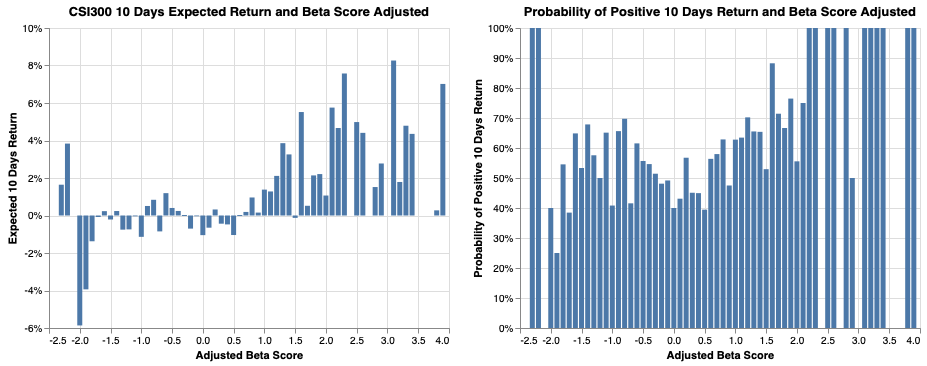

```python
# prepare data
price_df['next_10_days_return']=(price_df.close.shift(-10)-price_df.close)/price_df.close
chart_df = price_df.loc[:,['beta_score_adjusted','next_10_days_return']].dropna()
chart_df['over_zero'] = chart_df.next_10_days_return>0
chart_df.over_zero = chart_df.over_zero.astype('int')
chart_df.beta_score_adjusted = chart_df.beta_score_adjusted.round(1)
chart1_df = chart_df.groupby(by = 'beta_score_adjusted').mean().drop(columns='over_zero').reset_index()
chart2_df = (chart_df.drop(columns = 'next_10_days_return').groupby(by = 'beta_score_adjusted').sum()/chart_df.drop(columns = 'next_10_days_return').groupby(by = 'beta_score_adjusted').count()).reset_index()
# plot chart
chart1 = alt.Chart(chart1_df).mark_bar().encode(
    alt.X('beta_score_adjusted:Q', title ='Adjusted Beta Score'),
    alt.Y('next_10_days_return:Q',axis=alt.Axis(format='%'),title = 'Expected 10 Days Return')
).properties(title = 'CSI300 10 Days Expected Return and Beta Score Adjusted')

chart2 = alt.Chart(chart2_df).mark_bar().encode(
    alt.X('beta_score_adjusted:Q', title ='Adjusted Beta Score'),
    alt.Y('over_zero',axis=alt.Axis(format='%'),title = 'Probability of Positive 10 Days Return')
).properties(title = 'Probability of Positive 10 Days Return and Beta Score Adjusted')

chart1|chart2
```

```python
print('Correlation between adjusted beta score indicator and expected 10 days return of CSI300 is {}'.format(chart1_df.corr().iloc[1,0]))
print('Correlation between adjusted beta score indicator and probability of positive 10 days return of CSI300 is {}'.format(chart2_df.corr().iloc[1,0]))
```

```
Correlation between adjusted beta score indicator and expected 10 days return of CSI300 is 0.6681638555056763
Correlation between adjusted beta score indicator and probability of positive 10 days return of CSI300 is 0.5872755346006713
```

As we can see there's a clear positive correlation between our indicator and stock return, however the monotonicity is not good enough. Especially on the left side of the index, when the indicator value decreases we don't see a clear declining trend in stock return. To fix this problem, one idea is to amplify the monotonicity one the right side of the scale. To accomplish that we can multiply our adjusted beta score with beta value again and make the new indicator positively skewed.

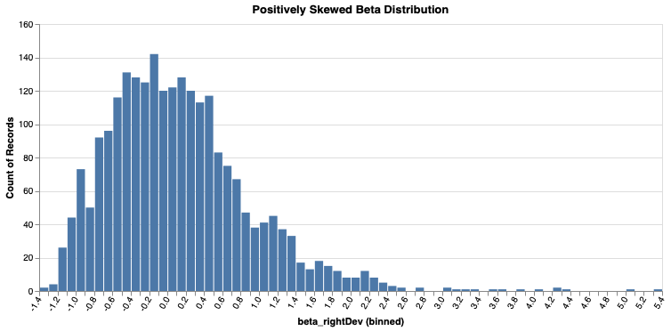

```python
price_df['beta_rightDev'] = price_df.beta_score_adjusted*price_df.beta
#plot distribution chart
alt.Chart(price_df.dropna()).mark_bar().encode(
    alt.X("beta_rightDev:Q", bin=alt.Bin(step=0.1),axis=alt.Axis(labelAngle=-60)),
    y='count()',
).properties(title = 'Positively Skewed Beta Distribution',width=700)
```

```python
describe(price_df.beta_rightDev)
```

```
count       2362.000000
mean           0.119688
std            0.777408
min           -1.333393
25%           -0.432765
50%            0.020123
75%            0.515874
max            5.318418
Kurtosis       3.375127
Skewness       1.216835
Name: beta_rightDev, dtype: float64
```

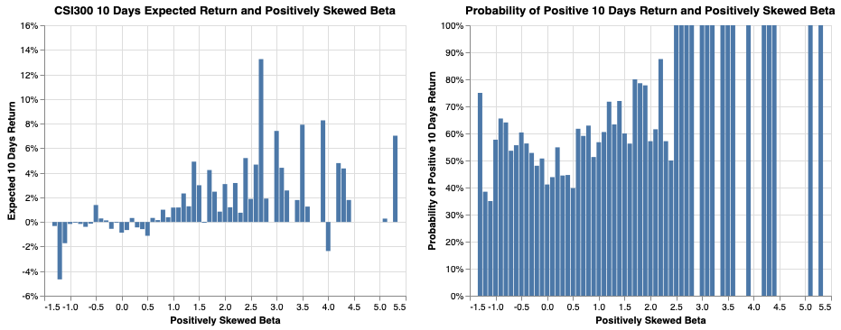

```python
chart_df = price_df.loc[:,['beta_rightDev','next_10_days_return']].dropna()
chart_df['over_zero'] = chart_df.next_10_days_return>0
chart_df.over_zero = chart_df.over_zero.astype('int')
chart_df.beta_rightDev = chart_df.beta_rightDev.round(1)
chart1_df = chart_df.groupby(by = 'beta_rightDev').mean().drop(columns='over_zero').reset_index()
chart2_df = (chart_df.drop(columns = 'next_10_days_return').groupby(by = 'beta_rightDev').sum()/chart_df.drop(columns = 'next_10_days_return').groupby(by = 'beta_rightDev').count()).reset_index()
# plot chart
chart1 = alt.Chart(chart1_df).mark_bar().encode(
    alt.X('beta_rightDev:Q', title ='Positively Skewed Beta'),
    alt.Y('next_10_days_return:Q',axis=alt.Axis(format='%'),title = 'Expected 10 Days Return')
).properties(title = 'CSI300 10 Days Expected Return and Positively Skewed Beta')

chart2 = alt.Chart(chart2_df).mark_bar().encode(
    alt.X('beta_rightDev:Q', title ='Positively Skewed Beta'),
    alt.Y('over_zero',axis=alt.Axis(format='%'),title = 'Probability of Positive 10 Days Return')
).properties(title = 'Probability of Positive 10 Days Return and Positively Skewed Beta')

chart1|chart2
```

```python
print('Correlation between positively skewed beta indicator and expected 10 days return of CSI300 is {}'.format(chart1_df.corr().iloc[1,0]))
print('Correlation between positively skewed beta and probability of positive 10 days return of CSI300 is {}'.format(chart2_df.corr().iloc[1,0]))
```

```
Correlation between positively skewed beta indicator and expected 10 days return of CSI300 is 0.5933507571496213
Correlation between positively skewed beta and probability of positive 10 days return of CSI300 is 0.6542083537999066
```

The distribution for adjusted indicator has more data fall on the tails so the correlation didn't show much improvement. But if we look at the chart, it did fix the monotonicity problem on the left side of the scale. I think we are ready to test whether the indicator works through our simple backtesting system.

## 3. Model Testing

We'll set the buy and sell signal threshold to 0.7 and -0.7. When the indicator value cross over 0.7 triger buy signal and hold the stock till the indicator cross below -0.7.

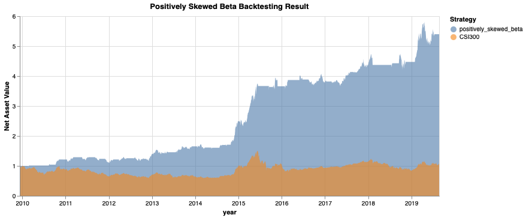

```python
# calculate holding status dataset
signal_df = pd.DataFrame({
    'buy_signal':price_df.beta_rightDev.dropna()>0.7,
    'sell_signal':price_df.beta_rightDev.dropna()<-0.7
})
signal_df['hold_status'] = signal_df.buy_signal
signal_df.loc[set(signal_df.loc[signal_df.buy_signal!=True].index).intersection(set(signal_df.loc[signal_df.sell_signal!=True].index)),'hold_status']=np.nan
signal_df.fillna(method='ffill',inplace=True)
signal_df.hold_status = signal_df.hold_status.astype(bool)
Beta_holdStatus = signal_df.hold_status.shift(1).dropna()
# plotting chart
chart_df = cal_NAV(Beta_holdStatus,'positively_skewed_beta')
alt.Chart(chart_df).mark_area(opacity=0.6).encode(
                    x = alt.X('index:T',title = 'year'),
                    y=alt.Y("value:Q", stack=None, title = 'Net Asset Value'),
                    color = alt.Color('variable:N',title = 'Strategy',sort = ['positively_skewed_beta','CSI300'])
                ).properties(title = 'Positively Skewed Beta Backtesting Result',width=700)
```

As you can see from the back testing chart the result looks amazing. We have successfully escaped most pull backs quite effectively. We are ready to use it in the real world to guide our investment timing, managing position etc.